# midexam_2

b06208016楊鎧綾

November 28, 2018

## 1

### 1-1

#### (1)

```r
mu=60;sigma=6;n=36
mean=mu;mean
```

```
## [1] 60
```

```r
sd=sigma/sqrt(n);sd
```

```
## [1] 1
```

**the sampling distribution is: mean=60, standard deviation=1**

#### (2)

```r
z=qt((1-0.95)/2, df = 35, lower.tail = FALSE)
A=mean-z*sd;A
```

```
## [1] 57.96989
```

```r
B=mean+z*sd;B
```

```
## [1] 62.03011
```

**A is 57.97, B is 62.03**,which has 95% the mean of speed will between it

#### (3)

**the result is not consistent with the belief**, because it is not in the interval calculate in part(2), which means it is out of mean for 2 standard deviation that contain 95% of sampling

### 1-2

#### (1)

```r
prop.test(x=c(0.611*131,0.426*61),n=c(131,61),alternative = "two.sided",conf.level = 0.99)
```

```
##
##  2-sample test for equality of proportions with continuity
##  correction
##
## data:  c(0.611 * 131, 0.426 * 61) out of c(131, 61)
## X-squared = 5.0367, df = 1, p-value = 0.02482
## alternative hypothesis: two.sided
## 99 percent confidence interval:
##  -0.02357028  0.39357028
## sample estimates:
## prop 1 prop 2
##  0.611  0.426
```

**the confidence interval is(-0.024,0.394)**

#### (2)

```r
prop.test(x=c(0.611*131,0.426*61),n=c(131,61),alternative = "two.sided",conf.level = 0.95)
```

```
##
##  2-sample test for equality of proportions with continuity
##  correction
##
## data:  c(0.611 * 131, 0.426 * 61) out of c(131, 61)
## X-squared = 5.0367, df = 1, p-value = 0.02482
## alternative hypothesis: two.sided
## 95 percent confidence interval:
##  0.02342526 0.34657474
## sample estimates:
## prop 1 prop 2
##  0.611  0.426
```

**the confidence interval is narrower in 95% confidence level**,  
because lower confidence level reduce the abs(z-score),which means the **margion of error will reduce** and narrow the interval

#### (3)

**yes it contains 0**,  
**contains 0 means it may be no difference between woman and man on dating someone not attractive under 99%confidence level**

## 2

### (1)

step.1  
null hypothesis:使用BRT-B的比例沒有比較高  
alternative hypothesis:使用BRT-B的比例有比較高  
$H_0$:p=0.2  
$H_a$:p > 0.2  
p 代表沿線居民使用BRT-B的比例

step.2 the sample is random selected and is big enough，so calculate the z-score is 1.77

```r
sd=sqrt((0.2*0.8)/200)
z=(0.25-0.20)/sd
z
```

```
## [1] 1.767767
```

step.3 the p-value is 0.039

```r
pnorm(z, lower.tail = FALSE)
```

```
## [1] 0.03854994
```

```r
prop.test(x = 50, n = 200,
          p = 0.2, alternative = "greater",
          conf.level = 0.95, correct = F)
```

```
##
##  1-sample proportions test without continuity correction
##
## data:  50 out of 200, null probability 0.2
## X-squared = 3.125, df = 1, p-value = 0.03855
## alternative hypothesis: true p is greater than 0.2
## 95 percent confidence interval:
##  0.2031997 1.0000000
## sample estimates:
##    p
## 0.25
```

step.4 the p-value is smaller than $\alpha=0.05$,so it is statically significant evidence to conclude that **null hypothesis is wrong**，we can reject the null value  
step.5 so we can say that 使用BRT-B的比例有比較高, **交通局不應該建議縣長終止BRT-B的服務**

### (2)

step.1  
null hypothesis:使用BRT-O 的比例沒有高過BRT-B  
alternative hypothesis:使用BRT-O 的比例高過BRT-B  
$H_0$:p1-p2=0  
$H_a$:p1-p2 > 0  
p1-p2 means the difference proportion of the use of BRT-O and BRT-B  
step.2 the sample is random selected and is big enough，so calculate the z-score which is 1.12

```r
p1=60/200;n1=200
p2=50/200;n2=200
phat=(n1*p1+n2*p2)/(n1+n2)
z=(p1-p2-0)/sqrt(phat*(1-phat)*((1/n1)+(1/n2)))
z
```

```
## [1] 1.119785
```

step.3 the p-value is 0.13

```r
pnorm(z, lower.tail = FALSE)
```

```
## [1] 0.1314027
```

```r
prop.test(x = c(60, 50), n = c(200,200),
          alternative = "greater",
          conf.level = 0.95, correct = F)
```

```
##
##  2-sample test for equality of proportions without continuity
##  correction
##
## data:  c(60, 50) out of c(200, 200)
## X-squared = 1.2539, df = 1, p-value = 0.1314
## alternative hypothesis: greater
## 95 percent confidence interval:
##  -0.02332985  1.00000000
## sample estimates:
## prop 1 prop 2
##   0.30   0.25
```

step.4 the p-value is larger than 0.05,so it is not statically significant evidence to conclude null hypothesis is wrong，we cannot reject the null value

step.5 so we can say that 使用BRT-O 的比例沒有高過BRT-B,兩者幾乎無差別,**交通局不應該建議縣長實現BRT-O的服務**

### (3)

因為$\alpha=0.05$,而此題為單尾檢定所以如果要計算信賴區間，他的信心水準是90%

```r
brt_b=prop.test(x=50,n=200,alternative = "two.sided",conf.level = 0.90)
brt_b$conf.int
```

```
## [1] 0.2008983 0.3061036
## attr(,"conf.level")
## [1] 0.9
```

```r
brt_o=prop.test(x=60,n=200,alternative = "two.sided",conf.level = 0.90)
brt_o$conf.int
```

```
## [1] 0.2473182 0.3582691
## attr(,"conf.level")
## [1] 0.9
```

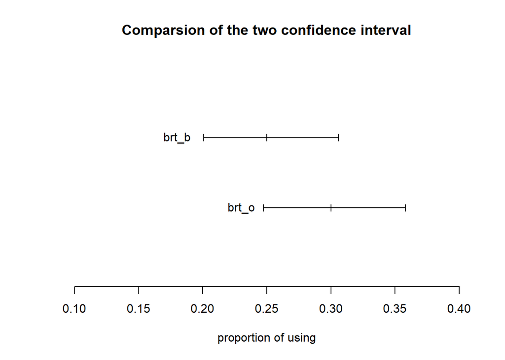

```r
plot(c(0,3),type='n',xlim=c(0.1,0.4),xlab='proportion of using',ylab='',axes=F,
     main='Comparsion of the two confidence interval')

lines(c(0.2008983,0.3061036),c(2,2))
text(0.18,2,labels='brt_b')
lines(c(0.2008983,0.2008983),c(1.95,2.05))
lines(c(0.3061036,0.3061036),c(1.95,2.05))
lines(c(0.25,0.25),c(1.95,2.05))

lines(c(0.2473182,0.3582691),c(1,1))
text(0.23,1,labels='brt_o')
lines(c(0.2473182,0.2473182),c(0.95,1.05))
lines(c(0.3582691,0.3582691),c(0.95,1.05))
lines(c(0.3,0.3),c(0.95,1.05))

axis(1)
```

**兩者的信賴區間大量重疊，因此可能是無差別的，與第2小題假說檢定的結果一致，BRT_O的預計使用率並沒有比較高**

## 3

### (1)

step.1  
null hypothesis:使用大眾運輸的通勤時間沒有較長  
alternative hypothesis:使用大眾運輸的通勤時間較長  
$H_0:\mu_1-\mu_2=0$  
$H_a:\mu_1-\mu_2 > 0$  
$\mu_1$ 代表使用大眾運輸的通勤時間;$\mu_2$ 代表開車的通勤時間  
step.2 the sample size is big enough to continue hypothesis test, the t-score=2.236(unpooled,unpooled is better all the time)

```r
se=sqrt((20^2/100)+(10^2/100))
t_score=((35-30)-0)/se;t_score
```

```
## [1] 2.236068
```

step.3 the p-value=0.013;df是取n1-1與n2-1較小者

```r
pt(t_score,df=99,lower.tail = F)
```

```
## [1] 0.01379615
```

step.4 set alpha=0.05,the p-value is smaller than alpha, so we can reject null hypothesis  
step.5 we can say that 使用大眾運輸的通勤時間較長  
**交通局可說在台北使用大眾運輸的通勤時間較長**

### (2)

step.1  
null hypothesis:使用大眾運輸的通勤時間沒有變短  
alternative hypothesis:使用大眾運輸的通勤時間有變短  
$H_0:\mu_d=0$  
$H_a:\mu_d < 0$  
$\mu_d$ 代表計畫完成前後使用大眾運輸的通勤時間差  
step.2 the sample size is big enough to continue hypothesis test, the t-score=-2

```r
mud=-1
s=5
t_score=(-1-0)/(5/sqrt(100));t_score
```

```
## [1] -2
```

step.3 the p-value=0.024

```r
pt(t_score,df=99)
```

```
## [1] 0.02411985
```

step.4 set alpha=0.05,the p-value is smaller than alpha, so we can reject null hypothesis  
step.5 we can say that 使用大眾運輸的通勤時間有變短  
**交通局可說計畫減少了在台北使用大眾運輸的通勤時間**

### (3)

#### 由顯著水準

step.1  
null hypothesis:計畫後使用大眾運輸的通勤時間與開車的時間無差異  
alternative hypothesis:計畫後使用大眾運輸的通勤時間與開車的時間有差異  
$H_0:\mu_3-\mu_2=0$  
$H_a:\mu_3-\mu_2 \neq 0$  
$\mu_3$ 代表計畫完成後使用大眾運輸的通勤時間;$\mu_2$ 代表開車的通勤時間  
step.2 the sample size is big enough to continue hypothesis test, the t-score=1.77(unpooled)

```r
se=sqrt((10^2/100)+(10^2/100))
t_score=((32.5-30)-0)/se;t_score
```

```
## [1] 1.767767
```

step.3 the p-value=0.080

```r
2*pt(t_score,df=99,lower.tail = F)
```

```
## [1] 0.08018078
```

step.4 set alpha=0.05,**the p-value is LARGER than alpha, so we cannot reject null hypothesis**  
step.5 we can say that 計畫後使用大眾運輸的通勤時間與開車的時間無差異  
**交通局可說計畫使使用大眾運輸的通勤時間與開車的時間無差異**

#### 由效應值

```r
se=sqrt((10^2/100)+(10^2/100))
t_score=((32.5-30)-0)/se
dhat=t_score*sqrt((1/100+1/100))
dhat
```

```
## [1] 0.25
```

**由於dhat=0.25最接近0.2,可以說幾乎看不出差別(effect size is small),交通局可說計畫使使用大眾運輸的通勤時間與開車的時間無差異**

## 4

### (1)

#### 資料準備

```r
data<-read.csv("pennstate2.csv")
```

```r
str(data)
```

```
## 'data.frame':    205 obs. of  8 variables:
##  $ s  : Factor w/ 2 levels "F","M": 1 2 2 1 2 1 2 2 1 1 ...
##  $ e  : int  2 0 2 2 4 9 0 0 6 4 ...
##  $ t  : Factor w/ 2 levels "N","Y": 1 1 1 1 2 2 1 1 1 1 ...
##  $ c  : int  25 47 50 50 50 70 162 150 50 30 ...
##  $ h  : num  70 77 71 65 74 61 76 73 65 63 ...
##  $ h.1: num  70 77 71 65 72 65 76 76 69 66 ...
##  $ l  : num  4 6 5 4 5 7 4 4 4 5 ...
##  $ f  : Factor w/ 3 levels "N","O","S": 2 1 2 2 1 2 3 1 1 1 ...
```

```r
str(data[data$t=="Y",])
```

```
## 'data.frame':    31 obs. of  8 variables:
##  $ s  : Factor w/ 2 levels "F","M": 2 1 2 2 1 2 1 1 2 2 ...
##  $ e  : int  4 9 1 0 2 2 5 5 2 0 ...
##  $ t  : Factor w/ 2 levels "N","Y": 2 2 2 2 2 2 2 2 2 2 ...
##  $ c  : int  50 70 30 200 40 78 200 27 40 50 ...
##  $ h  : num  74 61 70 73 69.5 71 69 67 70 75 ...
##  $ h.1: num  72 65 74 77 71 77 69 69 72 77 ...
##  $ l  : num  5 7 7 7 5 5 0 3 6 3 ...
##  $ f  : Factor w/ 3 levels "N","O","S": 1 2 1 3 2 2 2 1 3 1 ...
```

#### hypothesis test

step.1  
null hypothesis:沒有超過20%的同學運動量達標  
alternative hypothesis:有超過20%的同學運動量達標  
$H_0$:p=0.2  
$H_a$:p > 0.2  
p means the proportion of the students that exercise good  
step.2 the sample is random selected and is big enough，so calculate the z-score which is -1.75

```r
phat=31/205;n=205
z=(phat-0.2)/sqrt(0.2*0.8/n)
z
```

```
## [1] -1.746076
```

step.3 the p-value is 0.9596

```r
pnorm(z,lower.tail = F)
```

```
## [1] 0.9596011
```

```r
prop.test(x = 31, n = 205,
          p = 0.2, alternative = "greater",
          conf.level = 0.95, correct = F)
```

```
##
##  1-sample proportions test without continuity correction
##
## data:  31 out of 205, null probability 0.2
## X-squared = 3.0488, df = 1, p-value = 0.9596
## alternative hypothesis: true p is greater than 0.2
## 95 percent confidence interval:
##  0.1146222 1.0000000
## sample estimates:
##         p
## 0.1512195
```

step.4 the p-value is larger than 0.05,so it is not statically significant evidence to conclude null hypothesis is wrong，we cannot reject the null value

step.5 so we can say that 沒有超過20%的同學運動量達標,**校方不可說有超過20%的同學達標**

### (2)

#### 資料準備

```r
b<-data[data$s=="F",]
str(b)
```

```
## 'data.frame':    137 obs. of  8 variables:
##  $ s  : Factor w/ 2 levels "F","M": 1 1 1 1 1 1 1 1 1 1 ...
##  $ e  : int  2 2 9 6 4 3 4 2 5 2 ...
##  $ t  : Factor w/ 2 levels "N","Y": 1 1 2 1 1 1 1 1 1 2 ...
##  $ c  : int  25 50 70 50 30 50 50 30 40 40 ...
##  $ h  : num  70 65 61 65 63 64 67 67 64.5 69.5 ...
##  $ h.1: num  70 65 65 69 66 67 67 68 64.5 71 ...
##  $ l  : num  4 4 7 4 5 3 3 2 5 5 ...
##  $ f  : Factor w/ 3 levels "N","O","S": 2 2 2 1 1 1 1 3 1 2 ...
```

```r
str(b[b$t=="Y",])
```

```
## 'data.frame':    18 obs. of  8 variables:
##  $ s  : Factor w/ 2 levels "F","M": 1 1 1 1 1 1 1 1 1 1 ...
##  $ e  : int  9 2 5 5 7 8 6 7 5 5 ...
##  $ t  : Factor w/ 2 levels "N","Y": 2 2 2 2 2 2 2 2 2 2 ...
##  $ c  : int  70 40 200 27 80 75 20 100 60 65 ...
##  $ h  : num  61 69.5 69 67 67 68 67 64 66 61 ...
##  $ h.1: num  65 71 69 69 67 65 67 66 70 68 ...
##  $ l  : num  7 5 0 3 4 6 5 4 6 5 ...
##  $ f  : Factor w/ 3 levels "N","O","S": 2 2 2 1 3 2 2 2 2 3 ...
```

```r
p_f=18/137
c<-data[data$s=="M",]
str(c)
```

```
## 'data.frame':    68 obs. of  8 variables:
##  $ s  : Factor w/ 2 levels "F","M": 2 2 2 2 2 2 2 2 2 2 ...
##  $ e  : int  0 2 4 0 0 1 0 0 0 0 ...
##  $ t  : Factor w/ 2 levels "N","Y": 1 1 2 1 1 2 1 1 1 2 ...
##  $ c  : int  47 50 50 162 150 30 75 100 15 200 ...
##  $ h  : num  77 71 74 76 73 70 74 71 74 73 ...
##  $ h.1: num  77 71 72 76 76 74 77 74 74 77 ...
##  $ l  : num  6 5 5 4 4 7 4 4 5 7 ...
##  $ f  : Factor w/ 3 levels "N","O","S": 1 2 1 3 1 1 1 1 3 3 ...
```

```r
str(c[c$t=="Y",])
```

```
## 'data.frame':    13 obs. of  8 variables:
##  $ s  : Factor w/ 2 levels "F","M": 2 2 2 2 2 2 2 2 2 2 ...
##  $ e  : int  4 1 0 2 2 0 0 2 1 3 ...
##  $ t  : Factor w/ 2 levels "N","Y": 2 2 2 2 2 2 2 2 2 2 ...
##  $ c  : int  50 30 200 78 40 50 100 130 100 80 ...
##  $ h  : num  74 70 73 71 70 75 70 74 69 72 ...
##  $ h.1: num  72 74 77 77 72 77 73 74 72 74 ...
##  $ l  : num  5 7 7 5 6 3 4 4 5 6 ...
##  $ f  : Factor w/ 3 levels "N","O","S": 1 1 3 2 3 1 1 3 1 2 ...
```

```r
p_m=13/68
```

#### hypothesis test

step.1  
null hypothesis:男生運動量達標的比例沒有比女生高  
alternative hypothesis:男生運動量達標的比例比女生高  
$H_0$:p1-p2=0  
$H_a$:p1-p2 > 0  
p1-p2 means the difference proportion of 男女運動達標比例;p1為男生運動達標比例;p2為女生運動達標比例  
step.2 the sample is random selected and is big enough，so calculate the z-score which is 1.125

```r
p1=13/68;n1=68
p2=18/137;n2=137
phat=(n1*p1+n2*p2)/(n1+n2)
z=(p1-p2-0)/sqrt(phat*(1-phat)*((1/n1)+(1/n2)))
z
```

```
## [1] 1.125024
```

step.3 the p-value is 0.13

```r
pnorm(z, lower.tail = FALSE)
```

```
## [1] 0.1302894
```

```r
prop.test(x = c(13,18), n = c(68,137),
          alternative = "greater",
          conf.level = 0.95, correct = F)
```

```
##
##  2-sample test for equality of proportions without continuity
##  correction
##
## data:  c(13, 18) out of c(68, 137)
## X-squared = 1.2657, df = 1, p-value = 0.1303
## alternative hypothesis: greater
## 95 percent confidence interval:
##  -0.0318948  1.0000000
## sample estimates:
##    prop 1    prop 2
## 0.1911765 0.1313869
```

step.4 the p-value is larger than 0.05,so it is not statically significant evidence to conclude null hypothesis is wrong，we cannot reject the null value

step.5 so we can say that 男生運動量達標的比例沒有比女生高,**此調查結果無法支持校方宣稱**